# DSCI 352 Report Out 2

Anthony Brennan  
October 29, 2019

### Recap: Question

- Question
  - Can I predict an expected goal differential, total goals scored, and each team's chance of winning for various European soccer matches using player data from FIFA video games?

### Recap: Datasets

- 4 Datasets from Kaggle: Game data, player data from Fifa 17, 18, & 19
  - Applying Fifa 17 to 2016-17 season, Fifa 18 to 2017-18 season, and Fifa 19 to 2018-19 season
- Data for 17 leagues
  - England (1st-4th divisions)
  - Germany, France, Italy, Spain (1st-2nd divisions)
  - Belgium, Netherlands, Portugal, Scotland, Turkey (1st division)
- Total of 19314 games
- 334 teams and ~9500 players for each of the 3 years

### What I've Done Since Last Time

- For the most part finished cleaning the data
- Started working with training and testing data
- Started playing around with regression and SVM models
- Looking into methods to create probabilities for a home win, away win, and draw

### Subset Selection - Goal Differential

```r
w0 <- regsubsets(GoalDiff ~ HomeAttacking + AwayAttacking + HomeMidfield + AwayMidfield + HomeDefense + AwayDefense + HomeGoalkeeper + AwayGoalkeeper + HomeRest + AwayRest + RestDiff, training)
```

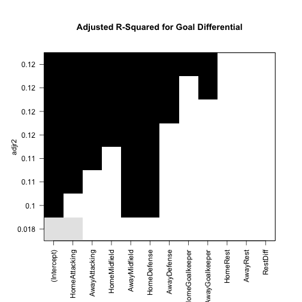

### Goal Differential (Goalkeepers) Regression

```
# A tibble: 9 x 5
  term           estimate std.error statistic   p.value
  <chr>             <dbl>     <dbl>     <dbl>     <dbl>
1 (Intercept)     -0.403    0.351       -1.15 0.251
2 HomeAttacking    0.0456   0.0115       3.96 0.0000772
3 AwayAttacking   -0.0395   0.0116      -3.42 0.000638
4 HomeMidfield     0.0494   0.0142       3.47 0.000516
5 AwayMidfield    -0.0530   0.0142      -3.74 0.000186
6 HomeDefense      0.0580   0.0149       3.89 0.0000996
7 AwayDefense     -0.0415   0.0152      -2.73 0.00626
8 HomeGoalkeeper   0.0112   0.00805      1.39 0.165
9 AwayGoalkeeper  -0.0195   0.00804     -2.43 0.0151
```

```
R-Squared = 0.120971
```

### Goal Differential (Goalkeepers) Plots

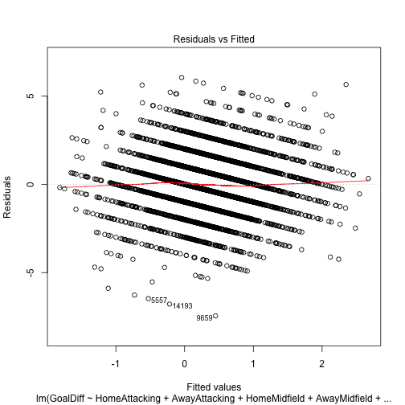

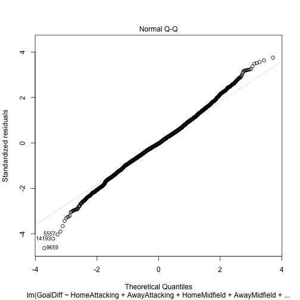

### Goal Differential (No Goalkeepers) Regression

```
# A tibble: 7 x 5
  term          estimate std.error statistic   p.value
  <chr>            <dbl>     <dbl>     <dbl>     <dbl>
1 (Intercept)    -0.336     0.339     -0.992 0.321
2 HomeAttacking   0.0470    0.0112     4.19  0.0000285
3 AwayAttacking  -0.0445    0.0113    -3.92  0.0000890
4 HomeMidfield    0.0532    0.0139     3.83  0.000132
5 AwayMidfield   -0.0602    0.0139    -4.33  0.0000149
6 HomeDefense     0.0624    0.0146     4.26  0.0000206
7 AwayDefense    -0.0484    0.0149    -3.25  0.00115
```

```
R-Squared = 0.119618
```

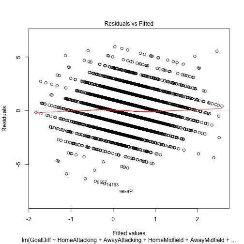

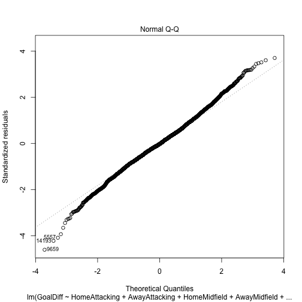

### Game Result Probabilities

Game 1

```
  Home_Away  Team Attacking Midfield Defense Goalkeeper
1      Home Milan      82.5    78.50      83         82
2      Away  Spal      71.5    69.75      68         72
```

[output not shown]

Game 2

```
  Home_Away     Team Attacking Midfield Defense Goalkeeper
1      Home Cagliari      75.5     74.5    75.0         75
2      Away   Torino      80.5     77.0    77.5         83
```

```
  Pred_Goal_Diff Home_Win Away_Win  Draw
1         -0.201    0.332    0.426 0.242
```

### Goal Differential SVM Model

```r
svm1 <- svm(GoalDiff ~ HomeAttacking + AwayAttacking + HomeMidfield + AwayMidfield + HomeDefense + AwayDefense + HomeGoalkeeper + AwayGoalkeeper, data = training, kernel = "linear", cost = 10, scale = FALSE)
```

10 sample predicted goal differentials

[output not shown]

### Next Steps

- Work on total goals scored models
- Look for additional variables that might be helpful predictors
- See if log or polynomial transformations are appropriate for some variables
- Research other modeling techniques to see if they can create a more accurate models
- Try and use poisson distributions to create more applicable result predictions for soccer's integer results
- Create a metric for bench players, since they are also involved in the game